# Final Part 2

2022-12-17

# Final Part 2

## Questions 1-4

1. There is a slightly, positively curved relationship between body length and body mass.
2. The body mass histogram has a relatively normal distribution, while the body length is disproportionately skewed. The body mass is relatively symmetrical on both sides of the mean, indicating normality. The body length histogram does not have this same distribution. Normally distributed data is important because it shows an even spread of the body lengths and masses. This would be expected where there is a mean and not a disproportionate amount of long dolomys.
3. The histograms seemed to show normality, however the Shapiro test rejected the null hypothesis for both body mass and body length therefore they are not normally distributed.

4.There seems to be a relationship between species for the body mass, where the data should be separated based on species. Sex has a difference in body mass for both species based on these boxplots.

```
## here() starts at C:/Users/ianbb/OneDrive - University of Massachusetts/UMass (student)/Courses/ECO602/environmental_data
```

```
##    Min. 1st Qu.  Median    Mean 3rd Qu.    Max.
##    49.0   106.0   116.0   114.7   124.0   265.0
```

```
##
##  Shapiro-Wilk normality test
##
## data:  delo_dat$body_length
## W = 0.87609, p-value < 2.2e-16
```

```
##    Min. 1st Qu.  Median    Mean 3rd Qu.    Max.
##    5.00   35.00   43.00   44.06   54.00  105.00
```

```
##
##  Shapiro-Wilk normality test
##
## data:  delo_dat$body_mass
## W = 0.99506, p-value = 4.33e-05
```

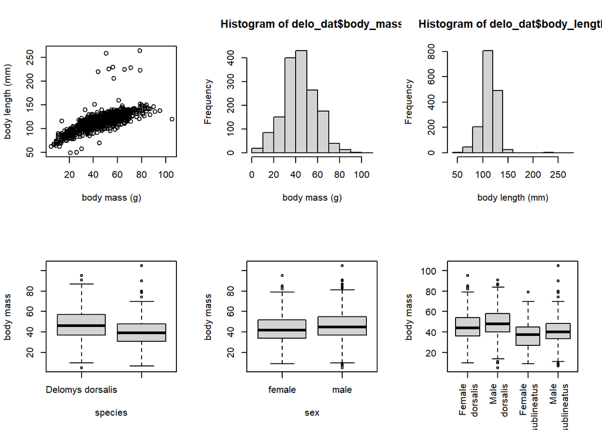

## Questions 5-6

5. The graphical tests of the residuals seemed to show they would be normally distributed. The Shapiro tests then denied that assumption because they all rejected the null hypothesis.
6. Fit2 was closer to not rejecting the null hypothesis, so it is more normally distributed than the others. Based on the results of the Shapiro Test, we can see deviations from the normality.

```r
anova(fit1)
```

```
## Analysis of Variance Table
##
## Response: delo_dat$body_length
##                      Df Sum Sq Mean Sq F value    Pr(>F)
## delo_dat$body_mass    1 269389  269389    1977 < 2.2e-16 ***
## Residuals          1583 215707     136
## ---
## Signif. codes:  0 '***' 0.001 '**' 0.01 '*' 0.05 '.' 0.1 ' ' 1
```

```r
anova(fit2)
```

```
## Analysis of Variance Table
##
## Response: delo_dat$body_mass
##                Df Sum Sq Mean Sq F value    Pr(>F)
## delo_dat$sex    1   3062 3061.68  13.943 0.0001951 ***
## Residuals    1578 346507  219.59
## ---
## Signif. codes:  0 '***' 0.001 '**' 0.01 '*' 0.05 '.' 0.1 ' ' 1
```

```r
anova(fit3)
```

```
## Analysis of Variance Table
##
## Response: delo_dat$body_mass
##                     Df Sum Sq Mean Sq F value    Pr(>F)
## delo_dat$binomial    1  21290 21289.7  102.08 < 2.2e-16 ***
## Residuals         1583 330164   208.6
## ---
## Signif. codes:  0 '***' 0.001 '**' 0.01 '*' 0.05 '.' 0.1 ' ' 1
```

```r
anova(fit4)
```

```
## Analysis of Variance Table
##
## Response: delo_dat$body_mass
##                     Df Sum Sq Mean Sq F value    Pr(>F)
## delo_dat$sex         1   3062  3061.7  14.958 0.0001144 ***
## delo_dat$binomial    1  23727 23727.1 115.923 < 2.2e-16 ***
## Residuals         1577 322780   204.7
## ---
## Signif. codes:  0 '***' 0.001 '**' 0.01 '*' 0.05 '.' 0.1 ' ' 1
```

```r
anova(fit5)
```

```
## Analysis of Variance Table
##
## Response: delo_dat$body_mass
##                                  Df Sum Sq Mean Sq  F value    Pr(>F)
## delo_dat$sex                      1   3062  3061.7  14.9489  0.000115 ***
## delo_dat$binomial                 1  23727 23727.1 115.8500 < 2.2e-16 ***
## delo_dat$sex:delo_dat$binomial    1      1     0.8   0.0039  0.950442
## Residuals                      1576 322779   204.8
## ---
## Signif. codes:  0 '***' 0.001 '**' 0.01 '*' 0.05 '.' 0.1 ' ' 1
```

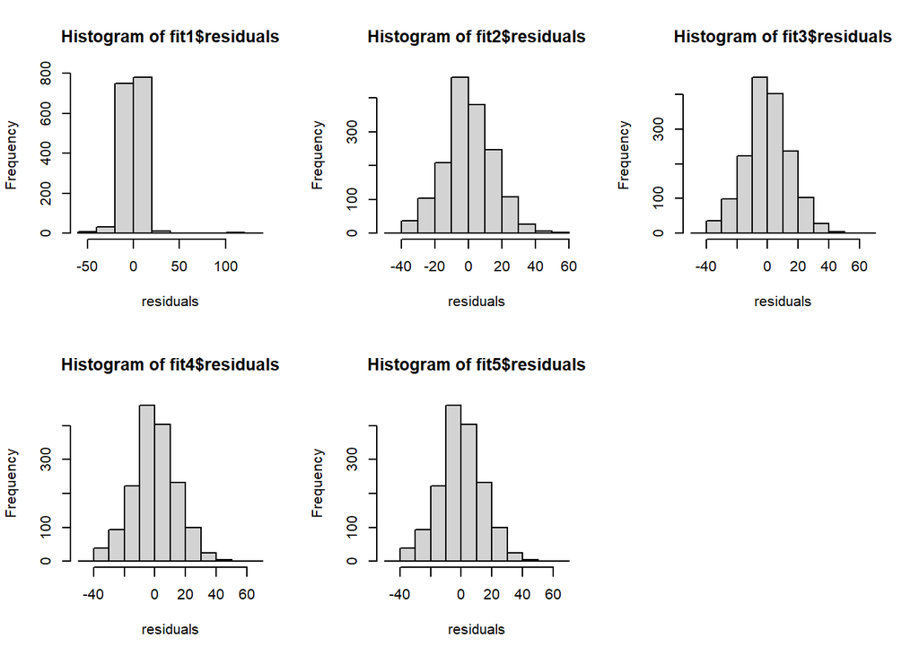

```r
par(mfrow = c(2,3))
hist(fit1$residuals, xlab = "residuals")
hist(fit2$residuals, xlab = "residuals")
hist(fit3$residuals, xlab = "residuals")
hist(fit4$residuals, xlab = "residuals")
hist(fit5$residuals, xlab = "residuals")
```

```r
shapiro.test(fit1$residuals)
```

```
##
##  Shapiro-Wilk normality test
##
## data:  fit1$residuals
## W = 0.73462, p-value < 2.2e-16
```

```r
shapiro.test(fit2$residuals)
```

```
##
##  Shapiro-Wilk normality test
##
## data:  fit2$residuals
## W = 0.99563, p-value = 0.0001541
```

```r
shapiro.test(fit3$residuals)
```

```
##
##  Shapiro-Wilk normality test
##
## data:  fit3$residuals
## W = 0.99535, p-value = 8.103e-05
```

```r
shapiro.test(fit4$residuals)
```

```
##
##  Shapiro-Wilk normality test
##
## data:  fit4$residuals
## W = 0.99525, p-value = 6.805e-05
```

```r
shapiro.test(fit5$residuals)
```

```
##
##  Shapiro-Wilk normality test
##
## data:  fit5$residuals
## W = 0.99526, p-value = 6.816e-05
```

```r
knitr::kable(coef(summary(fit1)))
```

|  | Estimate | Std. Error | t value | Pr(>\|t\|) |
| --- | --- | --- | --- | --- |
| (Intercept) | 76.1246565 | 0.9158120 | 83.12258 | 0 |
| delo_dat$body_mass | 0.8754988 | 0.0196905 | 44.46298 | 0 |

```r
knitr::kable(coef(summary(fit2)))
```

|  | Estimate | Std. Error | t value | Pr(>\|t\|) |
| --- | --- | --- | --- | --- |
| (Intercept) | 42.711465 | 0.5288929 | 80.756355 | 0.0000000 |
| delo_dat$sexmale | 2.784133 | 0.7456117 | 3.734024 | 0.0001951 |

```r
knitr::kable(coef(summary(fit3)))
```

|  | Estimate | Std. Error | t value | Pr(>\|t\|) |
| --- | --- | --- | --- | --- |
| (Intercept) | 46.752427 | 0.4499933 | 103.89582 | 0 |
| delo_dat$binomialDelomys sublineatus | -7.683058 | 0.7604562 | -10.10322 | 0 |

```r
knitr::kable(coef(summary(fit4)))
```

[output not shown]

```r
knitr::kable(coef(summary(fit5)))
```

[output not shown]

## 7-9

7. The magnitude is 0.8754988
8. 163.67 mm
9. 76.12 mm

```r
knitr::kable(coef(summary(fit1)))
```

|  | Estimate | Std. Error | t value | Pr(>\|t\|) |
| --- | --- | --- | --- | --- |
| (Intercept) | 76.1246565 | 0.9158120 | 83.12258 | 0 |
| delo_dat$body_mass | 0.8754988 | 0.0196905 | 44.46298 | 0 |

## 10-13

10. The base level is female.
11. The base level is dorsalis.
12. The male sex is heavier because the positive slope means it will increase from the starting female mass.
13. The dorsalis species is larger because the slope of -7 means sublineatus will always be smaller.

```r
knitr::kable(coef(summary(fit2)))
```

|  | Estimate | Std. Error | t value | Pr(>\|t\|) |
| --- | --- | --- | --- | --- |
| (Intercept) | 42.711465 | 0.5288929 | 80.756355 | 0.0000000 |
| delo_dat$sexmale | 2.784133 | 0.7456117 | 3.734024 | 0.0001951 |

```r
knitr::kable(coef(summary(fit3)))
```

|  | Estimate | Std. Error | t value | Pr(>\|t\|) |
| --- | --- | --- | --- | --- |
| (Intercept) | 46.752427 | 0.4499933 | 103.89582 | 0 |
| delo_dat$binomialDelomys sublineatus | -7.683058 | 0.7604562 | -10.10322 | 0 |

## 17-18

```r
AIC(
  fit2,
  fit3,
  fit4,
  fit5
)
```

```
##      df      AIC
## fit2  3 13006.80
## fit3  3 12966.36
## fit4  4 12896.73
## fit5  5 12898.72
```

```r
knitr::kable(coef(summary(fit4)))
```

[output not shown]

```r
knitr::kable(coef(summary(fit5)))
```

[output not shown]